# 1.5.2 - Beginner - Introduction to Data Visualization II

### Test your knowledge

Let’s now apply what we’ve learned with a few case studies. We will try to recreate a few different types of graphs with our PWT dataset!

#### Scatterplots

Let’s see if we can use our tools to recreate a graph similar to the one below using our PWT data set.

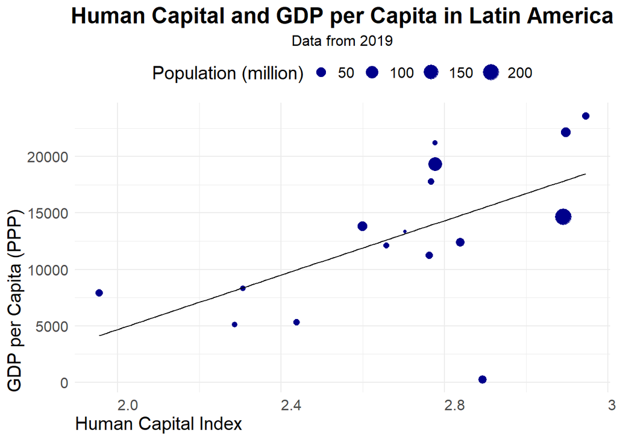

It’s highly recommended that you try to recreate the chart on your own before answering the questions below. The best way to learn data visualization in R is through practice.

```r
# try it yourself here

# use `rgdpe` as the measure for gdp

# to help you out: here is a vector with the countries we used in the plot

list_of_countries <- c("Peru", "Brazil", "Paraguay", "Colombia", "Uruguay", "Guatemala", "Chile", "Argentina", "Suriname", "Ecuador", "Bolivia", "Venezuela (Bolivarian Republic of)", "Mexico", "Nicaragua", "El Salvador", "Honduras", "Guyana", "Dominican Republic")
```

Once you’ve given this chart a try, answer the questions below to verify your understanding:

What command did we use for plotting the data?

```r
# Fill in the ... with your answer below (example: "geom_histogram")
answer_2 <- "geom_..."

test_2()
```

What aesthetics did we use to build the plot? Remember that the structure of `aes` is:

aes(x = …, y = …/…, size = …)

```r
# Fill in the "..." with the variables used - don't add or remove any of the quotations!
x <- "..."
y <- ".../..."
size <- "..."

answer_3 <- paste(x, y, size)   # don't change this

test_3()
```

How did we label our axes, legend, and subtitle? Make sure your answers are written exactly like the plot.

```r
# Fill in the ... with the labels used - don't add or remove any of the quotations or commas!

answer_4 <- "labs(x = ..., y = ..., size = ..., subtitle = ...)"

test_4()
```

How did we plot the line of best fit? Select the option that best completes the code skeleton below.

…(… = lm, se = …)

1. geom_point, method, FALSE
2. geom_smooth, fit, TRUE
3. geom_line, method, FALSE
4. geom_point, fit, TRUE
5. geom_smooth, method, FALSE
6. geom_line, fit, TRUE

```r
# Enter your answer as "A", "B", "C", "D", "E" or "F"
answer_5 <- "..."

test_5()
```